# Homework #5

Kateryna Mykhaylova

2/23/2022

Group Members: Kateryna Mykhaylova, Polina Semenova, Michael Moore

## Tips at Restaurants

#### Due: 3/2/2022 before 11:59pm. Submit in Canvas (file upload).

In this homework we will use the `tips` data set. This data set is part of the `reshape2` package. You can load the data set by executing the command:

```r
data(tips, package="reshape2")
```

The information contained in the data is collected by one waiter, who recorded over the course of a season information about each tip he received working in one restaurant. See `?tips` for a description of all of the variables.

```r
str(tips)
```

```
## 'data.frame':    244 obs. of  7 variables:
##  $ total_bill: num  17 10.3 21 23.7 24.6 ...
##  $ tip       : num  1.01 1.66 3.5 3.31 3.61 4.71 2 3.12 1.96 3.23 ...
##  $ sex       : Factor w/ 2 levels "Female","Male": 1 2 2 2 1 2 2 2 2 2 ...
##  $ smoker    : Factor w/ 2 levels "No","Yes": 1 1 1 1 1 1 1 1 1 1 ...
##  $ day       : Factor w/ 4 levels "Fri","Sat","Sun",..: 3 3 3 3 3 3 3 3 3 3 ...
##  $ time      : Factor w/ 2 levels "Dinner","Lunch": 1 1 1 1 1 1 1 1 1 1 ...
##  $ size      : int  2 3 3 2 4 4 2 4 2 2 ...
```

3. Create a new variable `size.factor` which translates the variable `size` to a factor. Should `size` be a factor or a numerical variable? Give your reasoning.  
   **Answer: Size should be a numerical variable, because it represents the size of the party and all the values are integers**

```r
tips$size.factor = as.factor(tips$size)
levels(tips$size.factor)
```

```
## [1] "1" "2" "3" "4" "5" "6"
```

4. How does the tipping amount (`tip`) depend on the overall bill (`total_bill`)? Use the `ggplot2` package to show a chart, describe the relationship in words. Describe at least two types of anomalies in the plot. What do they mean?  
   **Answer: As you can see from the scatter plot below we can see that there seems to be positive linear correlation between the two variables. We can see that at lower bills we have lower tips and vice verca. We can also see that there are some anomalies in the plot and data. For example there is a dot at ~$7 bill and ~$5 tip which would be a ~70% tip. We can see anomalies on the other ends to. For example on a ~$34 bill there was a ~$1.2 tip which would be a ~3.5%. These anomalies reflect nothing about the data, but everything about the person.**

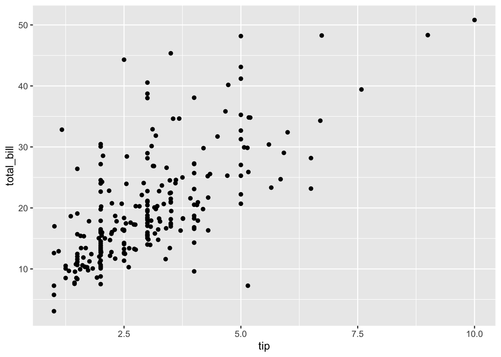

```r
tips %>% ggplot(aes(x = tip, y = total_bill)) +
  geom_point()
```

5. Introduce a variable `tiprate` into the data set, that incorporates the rate of tips. What information is available for the best tipper, what for the worst? What is the average rate for tips?  
   **Answer: The average rate for tips is 16.08%. The best tipper had a 71.03% tip, however, his total bill was only $7.25. The worst tipper had a 3.56% tip, he had a $32.83 bill.**

```r
tips$tiprate = (tips$tip / tips$total_bill) * 100
tips[tips$tiprate == max(tips$tiprate),]
```

```
##     total_bill  tip  sex smoker day   time size size.factor  tiprate
## 173       7.25 5.15 Male    Yes Sun Dinner    2           2 71.03448
```

```r
tips[tips$tiprate == min(tips$tiprate),]
```

```
##     total_bill  tip  sex smoker day   time size size.factor  tiprate
## 238      32.83 1.17 Male    Yes Sat Dinner    2           2 3.563814
```

```r
mean(tips$tiprate)
```

```
## [1] 16.08026
```

6. How does smoking behavior and gender of the person who pays impact the relationship between tip and total bill? Find a visualization that incorporates all four variables. Interpret the result.  
   **Answer: Based on the scatterplot we can see that smokers tip less and that it would seem males will tip more than females. This is a very loose correlation that is visible. More analysis of the data would be necesarry to say this for certian.**

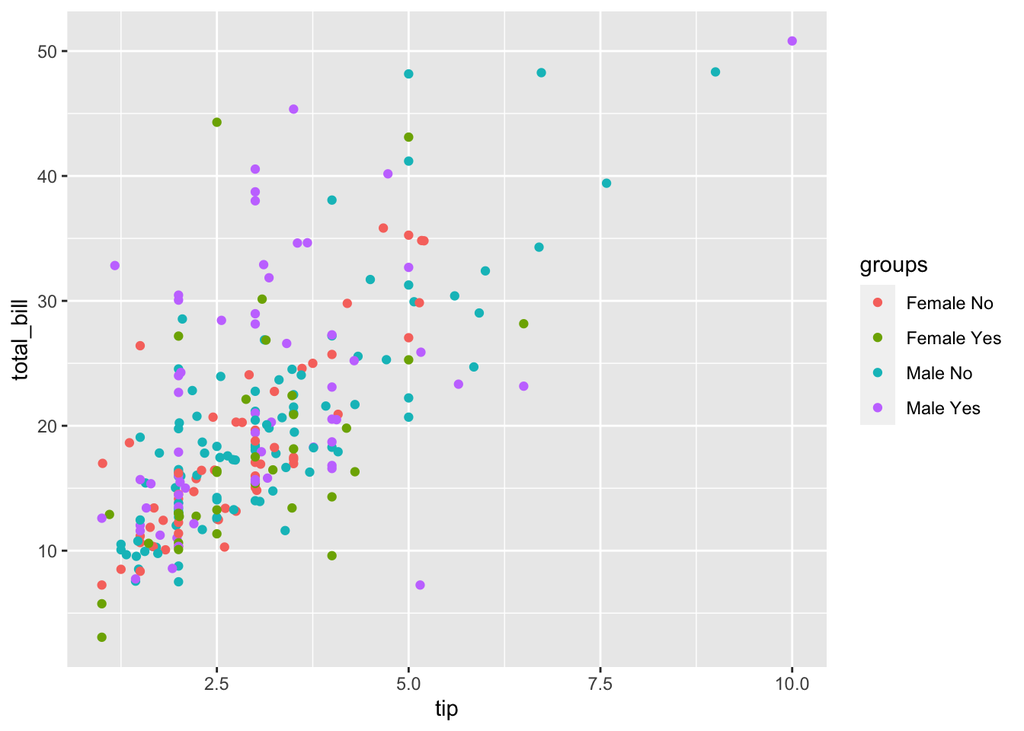

```r
tips1 <- tips %>% group_by(sex, smoker) %>% mutate(groups = paste(sex,smoker,sep=" "))
tips1 %>% ggplot(aes(x = tip, y = total_bill, color = groups)) +
  geom_point()
```

7. Use ggplot2 to find a graphical summary of the relationship between day of the week and gender of the person paying the bill. What can you say about this relationship?  
   **Answer: On the weekends males pay significantly more than females, but on weekdays females and males pay around the same.**

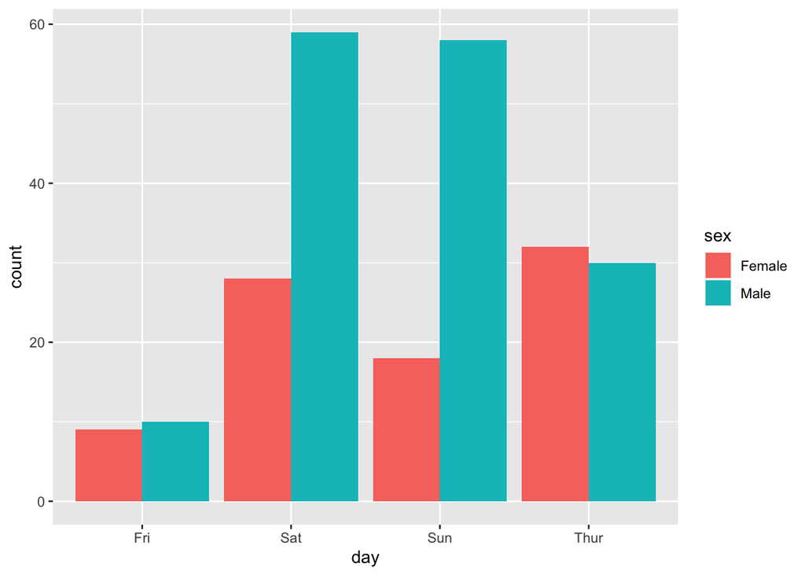

```r
tips %>% ggplot(aes(x = day, fill = sex)) +
  geom_bar(position = position_dodge())
```

8. Use ggplot2 to make a boxplot of the `tiprate` on different days. Rank the levels of `day` by the average of the `tiprate`. What can you say about this relationship?  
   **Answer: As we can see the tiprate is essentially the same for everyday. Ironically Saturday is lowest tip rate day when it would intuitively seem like the most.**

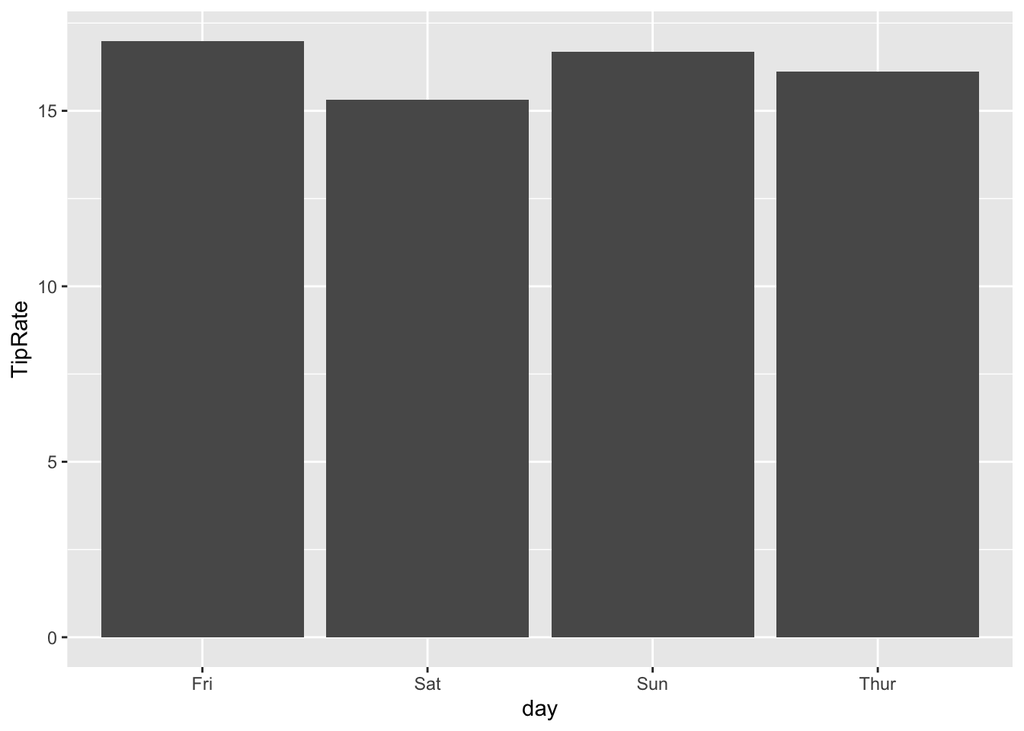

```r
tips2 <- ddply(tips, .(day), function(x) mean(x$tiprate))
names(tips2)[2] <- 'AverageRating'
tips2 %>% ggplot(aes(x = day)) +
 geom_bar(aes(weight = AverageRating)) +
  ylab("TipRate")
```

Note: your submission is supposed to be fully reproducible, i.e. the TA and I will ‘knit’ your submission in RStudio.

For the submission: submit your solution in an **R Markdown file** and (just for insurance) submit the **corresponding html (or Word)** file with it.